# PS

Projekt na przedmiot Rachunek Prawdopodobieństwa i Statystyka 2022/2023 Analiza statystyczna cech pingwinów z wysp Archipelagu PalmeraPotrzebne importy

```python
from palmerpenguins import load_penguins
import matplotlib.pyplot as plt
import seaborn as sns
import numpy as np
from sklearn.linear_model import LinearRegression
from scipy.stats import norm, kurtosis
from scipy.stats import kstest
import scipy.stats
```

Zgrywamy dataset i usuwamy puste pola

```python
df = load_penguins()
df.dropna(inplace=True)
penguins = sns.load_dataset('penguins')
penguins.dropna(inplace=True)
```

Chcemy dowiedzieć się podstawowych informacji o naszym datasetcie. Sprawdzamy minimalne i maksymalne wartości, średnie, odchylenia standardowe oraz kwartyle zmiennych.

```python
print(df.describe())
```

```
       bill_length_mm  bill_depth_mm  flipper_length_mm  body_mass_g  \
count      333.000000     333.000000         333.000000   333.000000
mean        43.992793      17.164865         200.966967  4207.057057
std          5.468668       1.969235          14.015765   805.215802
min         32.100000      13.100000         172.000000  2700.000000
25%         39.500000      15.600000         190.000000  3550.000000
50%         44.500000      17.300000         197.000000  4050.000000
75%         48.600000      18.700000         213.000000  4775.000000
max         59.600000      21.500000         231.000000  6300.000000

              year
count   333.000000
mean   2008.042042
std       0.812944
min    2007.000000
25%    2007.000000
50%    2008.000000
75%    2009.000000
max    2009.000000
```

Pokazujemy wykres ilości pingwinów z danego gatunku i płci

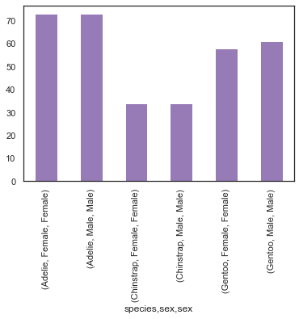

```python
penguins.groupby(['species','sex'])['sex'].value_counts().plot(kind='bar',color='#967BB6')
```

Jak widać najwięcej jest pingwinów Adelie. Widać też, że jest po równo płci.Sprawdzamy korelacje i kowariancję zmiennych.

```python
print(df.drop(['sex','year','species','island'],axis=1).cov())
print(df.drop(['sex','year','species','island'],axis=1).corr())
```

```
                   bill_length_mm  bill_depth_mm  flipper_length_mm  \
bill_length_mm          29.906333      -2.462091          50.058195
bill_depth_mm           -2.462091       3.877888         -15.947248
flipper_length_mm       50.058195     -15.947248         196.441677
body_mass_g           2595.623304    -748.456122        9852.191649

                     body_mass_g
bill_length_mm       2595.623304
bill_depth_mm        -748.456122
flipper_length_mm    9852.191649
body_mass_g        648372.487699
                   bill_length_mm  bill_depth_mm  flipper_length_mm  \
bill_length_mm           1.000000      -0.228626           0.653096
bill_depth_mm           -0.228626       1.000000          -0.577792
flipper_length_mm        0.653096      -0.577792           1.000000
body_mass_g              0.589451      -0.472016           0.872979

                   body_mass_g
bill_length_mm        0.589451
bill_depth_mm        -0.472016
flipper_length_mm     0.872979
body_mass_g           1.000000
```

Pokazujemy wizualne rozłożenie danych ze względu na gatunek

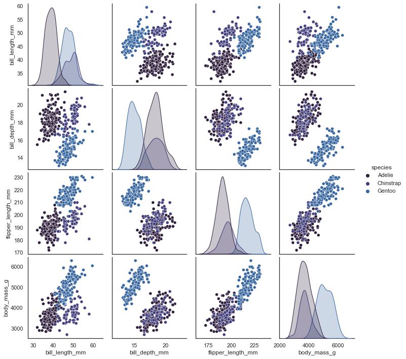

```python
sns.set(style="white", color_codes=True, palette='mako')
sns.pairplot(penguins,hue='species')
```

Pokazujemy wizualne rozłożenie danych ze względu na płeć

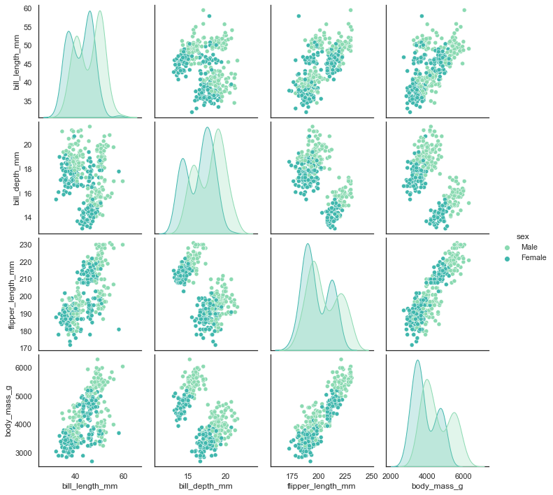

```python
sns.set(style="white", color_codes=True, palette='mako_r')
sns.pairplot(penguins,hue='sex')
```

```python
df.drop(['sex','year','island','species'],axis=1,inplace=True)
```

```python
Pokazujemy wykres zależności pomiędzy zmiennymi
```

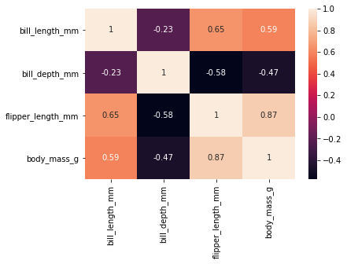

```python
sns.heatmap(df.corr(),annot=True)
```

Widać, że masa pingwina i długość płetwy są mocno zależne od siebie, a długość i głębokość dziobu są mało zależne od siebie

```python
Pokazujemy wykres masy od gatunku
```

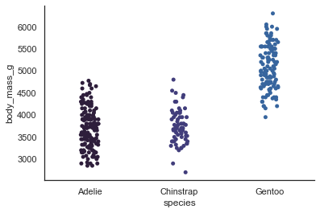

```python
sns.set(style="white", color_codes=True, palette='mako')
sns.stripplot(x='species', y='body_mass_g', data=penguins)
sns.despine()
```

Pokazujemy wykres masy od płci

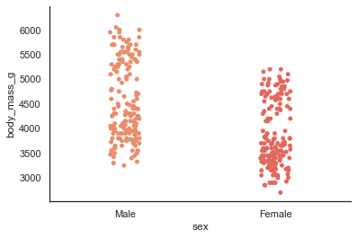

```python
sns.set(style="white", color_codes=True, palette='flare')
sns.stripplot(x='sex', y='body_mass_g', data=penguins)
sns.despine()
```

Pokazujemy wykres masy od gatunku i płci

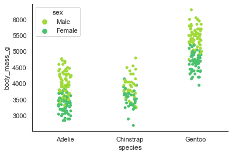

```python
sns.set(style="white", color_codes=True, palette='viridis_r')
sns.stripplot(x='species', y='body_mass_g', hue='sex', data=penguins)
sns.despine()
```

Pokazujemy wykres długości płetw od płci i gatunku

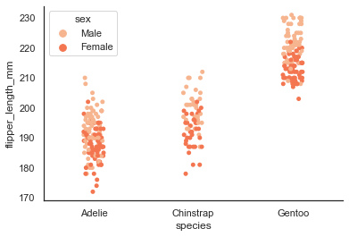

```python
sns.set(style="white", color_codes=True, palette='rocket_r')
sns.stripplot(x='species', y='flipper_length_mm', hue='sex', data=penguins)
sns.despine()
```

Pokazujemy wykres głębokości dziobu od płci i gatunku

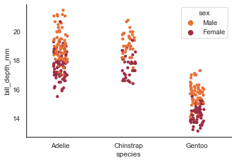

```python
sns.set(style="white", color_codes=True, palette='icefire_r')
sns.stripplot(x='species', y='bill_depth_mm', hue='sex', data=penguins)
sns.despine()
```

Pokazujemy wykres długości dziobu od płci oraz gatunku

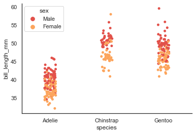

```python
sns.set(style="white", color_codes=True, palette='Spectral')
sns.stripplot(x='species', y='bill_length_mm', hue='sex', data=penguins)
sns.despine()
```

Sprawdzamy czy istnieje korelacja, więc tworzymy wykres regresji długości płetw od masy i wyliczamy wartości współczynników regresji

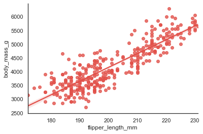

```python
sns.set(style="white", color_codes=True, palette='Spectral')
sns.regplot(x='flipper_length_mm',y='body_mass_g',data=penguins)
sns.despine()
```

```python
X = df.drop(['bill_length_mm','bill_depth_mm'],axis=1)
Y = df['body_mass_g']
reg = LinearRegression().fit(X, Y)
print(reg.score(X,Y))
print(reg.coef_)
print(reg.intercept_)
```

```
1.0
[5.91596047e-15 1.00000000e+00]
-1.8189894035458565e-12
```

Sprawdzamy czy rozkład głębokości dziobu jest rozkładem normalnym

```python
print(kurtosis(df['bill_depth_mm']))
```

```
-0.8965872511276172
```

```python
print(df['bill_depth_mm'].skew())
```

```
-0.1497202576146911
```

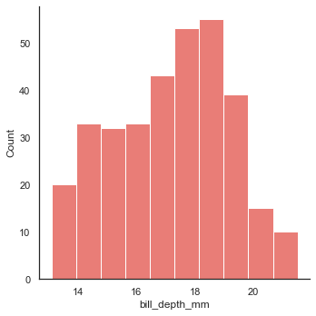

```python
sns.displot(penguins['bill_depth_mm'])
```

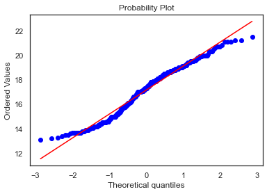

```python
scipy.stats.probplot(penguins['bill_depth_mm'],dist="norm", plot=plt)
plt.show()
```

```python
print(kstest(penguins['bill_depth_mm'],'norm'))
```

```
KstestResult(statistic=1.0, pvalue=0.0)
```